# data_exploration

```python
import pandas as pd

# Read the data file
df = pd.read_csv("../data/dataset.csv")
```

```python
df.head()
```

|  | domain | label |
| --- | --- | --- |
| 0 | http://sprint.com/business/solutions/mobility_... | 0.0 |
| 1 | hesperia.gsfc.nasa.gov/~schmahl/nnls/ | 0.0 |
| 2 | http://web.de/magazine/digital/sicher-im-netz/... | 0.0 |
| 3 | www.wired.com/science/discoveries/news/1999/08... | 0.0 |
| 4 | thomas.arnatt.com/wp-includes/pono/AOL_Logio.htm | 1.0 |

```python
# Columns types and dimension
print(df.columns)
print('-------------------')
print(df.shape)
print('-------------------')
print(df.dtypes)
print('-------------------')
```

```
Index(['domain', 'label'], dtype='object')
-------------------
(120990, 2)
-------------------
domain     object
label     float64
dtype: object
-------------------
```

```python
# check for missing values
df.isnull().sum()
```

```
domain    0
label     0
dtype: int64
```

```python
# check for duplicates
df.duplicated().sum()
```

```
0
```

### À propos du jeu de données

Le jeu de données contient **120990 entrées uniques**.  
Il y a deux colonnes.

1- La colonne 'Label' est la colonne de prédiction qui a 2 catégories :  
A. *légitime* (0) - ce qui signifie que l'URL ne contient pas de contenu malveillant et que ce site n'est pas un site d'hameçonnage (Phishing).  
B. *Mauvais* (1) - ce qui signifie que l'URL contient des contenus malveillants et que ce site est un site d'hameçonnage.

2- La colonne domain (URLs).

Il n'y a aucune valeur manquante dans le jeu de données.

### Vérifiez la distribution des classes.

```python
# Class distribution
df.groupby('label').size()
```

```
label
0.0    92680
1.0    28310
dtype: int64
```

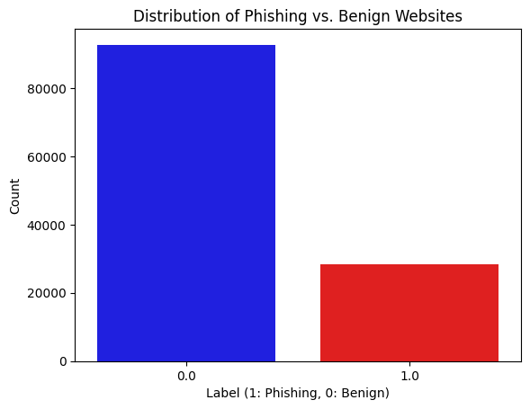

```python
import seaborn as sns
import matplotlib.pyplot as plt
%matplotlib inline

# class distribution
sns.countplot(x='label', data=df, palette=['blue', 'red'])
plt.title('Distribution of Phishing vs. Benign Websites')
plt.xlabel('Label (1: Phishing, 0: Benign)')
plt.ylabel('Count')
plt.show()
```

### Aperçus de l'analyse des données

**Signification du déséquilibre des classes :**

- **Classe majoritaire** : Sites web bénins *(étiquette 0.0)*
- **Classe minoritaire** : Sites web de phishing *(étiquette 1.0)*

#### Conséquences :

Le jeu de données présente un déséquilibre de classes significatif, soulevant des préoccupations quant au **potentiel de biais du modèle** en faveur des sites web bénins. Ceci pourrait conduire à une haute précision globale mais à des performances médiocres dans la détection des sites de phishing.

#### Solutions possibles pour contrebalancer le biais du modèle :

- **Suréchantillonnage** : Duplication des instances de sites de phishing dans le jeu de données.
- **Sous-échantillonnage** : Suppression aléatoire d'instances de sites web bénins.
- **Génération de données synthétiques (SMOTE)** : Création d'instances synthétiques de sites de phishing.

SMOTE est facile à mettre en œuvre et ne nécessite pas beaucoup d'effort, et sera pris en compte pendant la phase d'entraînement.

### Caractéristiques spécifiques pour la détection d'URLs de phishing

Lorsqu'on travaille sur la détection d'URL de phishing, il existe plusieurs caractéristiques spécifiques aux domaines qui peuvent nous aider à distinguer les URL légitimes des URL de phishing. Étudier ces caractéristiques pourrait aider à extraire des "features" pour entraîner le modèle :

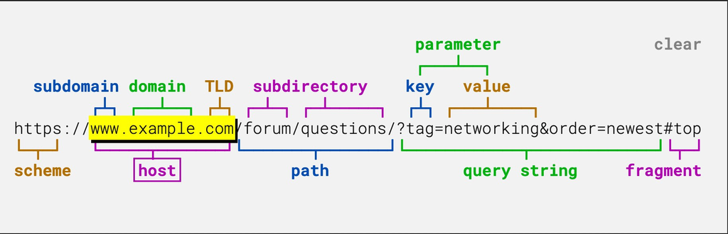

- **Adresse IP dans l'URL**  
  La présence d'une adresse IP dans l'URL peut être un indicateur de phishing. Les URLs légitimes utilisent généralement des noms de domaine plutôt que des adresses IP. Si la partie domaine de l'URL contient une adresse IP, cela peut être un signe que l'URL est malveillante.
- **Longueur de l'URL**  
  Les URLs de phishing sont souvent plus longues que les URLs légitimes. Les hameçonneurs peuvent utiliser une longue URL pour cacher la partie douteuse dans la barre d'adresse. Dans ce projet, si la longueur de l'URL est supérieure ou égale à 54 caractères, alors l'URL est classée comme de phishing.
- **Profondeur de l'URL**  
  La profondeur de l'URL est le nombre de sous-pages dans l'URL donnée en fonction du '/'. Les URLs de phishing peuvent avoir une profondeur d'URL plus élevée que les URLs légitimes. Cette caractéristique peut être utilisée pour aider à distinguer les URLs de phishing des URLs légitimes.
- **Redirection "//" dans l'URL**  
  La présence de "//" dans l'URL peut être un indicateur de phishing. L'existence de "//" à l'intérieur du chemin de l'URL signifie que l'utilisateur sera redirigé vers un autre site web. Si le "//" est présent n'importe où dans l'URL à part après le protocole, cela peut être un signe que l'URL est malveillante.
- **Utilisation des services de raccourcissement d'URL**  
  Les hameçonneurs peuvent utiliser des services de raccourcissement d'URL pour cacher l'URL réelle de leur site web malveillant. Si l'URL utilise des services de raccourcissement, cela peut être un signe que l'URL est de phishing.

### Références

*Beyond Blacklists: Learning to Detect Malicious Web Sites from Suspicious URLs*  
Justin Ma, Lawrence K. Saul, Stefan Savage, Geoffrey M. Voelker  
Department of Computer Science and Engineering

```
         count       mean        std  min   25%   50%   75%     max
label
0.0    92680.0  63.710887  51.333755  4.0  28.0  43.0  94.0  2081.0
1.0    28310.0  76.169905  67.426589  9.0  34.0  55.0  93.0  2175.0
```

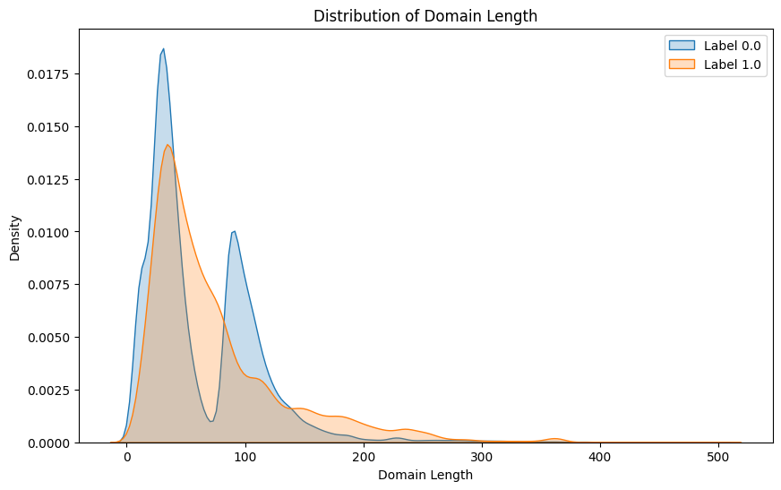

```python
import matplotlib.pyplot as plt
import seaborn as sns

df["domain_length"] = df["domain"].apply(len)
length_summary = df.groupby("label")["domain_length"].describe()
print(length_summary)

plt.figure(figsize=(10, 6))
for label in df["label"].unique():
    subset = df[df["domain_length"].between(0, 500) & (df["label"] == label)]
    sns.kdeplot(subset["domain_length"], fill=True, label=f"Label {label}", common_norm=False)

plt.title("Distribution of Domain Length")
plt.xlabel("Domain Length")
plt.ylabel("Density")
plt.legend()
plt.show()
```

**Importance pour le feature engineering:**

- **Feature "Longueur du domaine":** créer une variable numérique qui représente la longueur du domaine (en nombre de caractères).
- **Seuils de longueur:** on peut explorer l'utilisation de seuils de longueur pour classer les domaines. Par exemple, les domaines de plus de 30 caractères pourraient être considérés comme plus suspects.

```
         count      mean       std  min  25%  50%  75%   max
label
0.0    92680.0  1.192879  1.536087  0.0  0.0  1.0  2.0  30.0
1.0    28310.0  2.435853  3.144191 -1.0  1.0  1.0  3.0  36.0
```

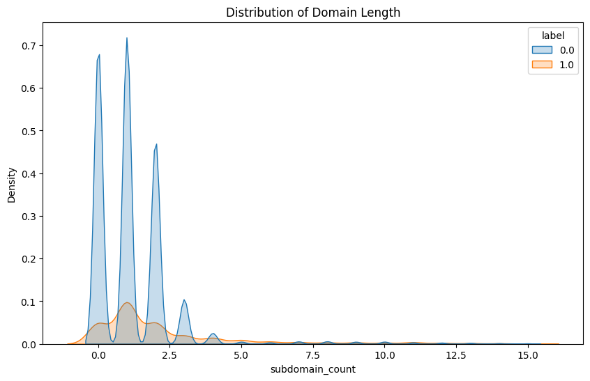

```python
def count_subdomains(url):
    return url.count('.') - 1

df['subdomain_count'] = df['domain'].apply(count_subdomains)
subdomain_summary = df.groupby('label')['subdomain_count'].describe()
print(subdomain_summary)

plt.figure(figsize=(10, 6))
sns.kdeplot(data=df[df['subdomain_count'].between(0, 15)], x='subdomain_count', hue='label', fill=True)
plt.title('Distribution of Domain Length')
plt.xlabel('subdomain_count')
plt.ylabel('Density')
plt.show()
```

**URLs légitimes (label 0):** Tendent à avoir des longueurs de sous-domaines plus courtes et des pics de densité plus élevés, ce qui suggère des structures de domaine plus simples et régulières.

**URLs de phishing (label 1):** Montrent des longueurs de sous-domaines plus variées et des pics moins prononcés, ce qui peut être dû à des tentatives de camouflage ou de complexité ajoutée pour tromper les utilisateurs.

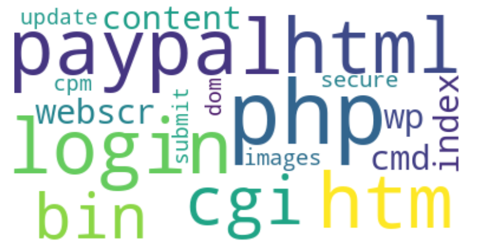

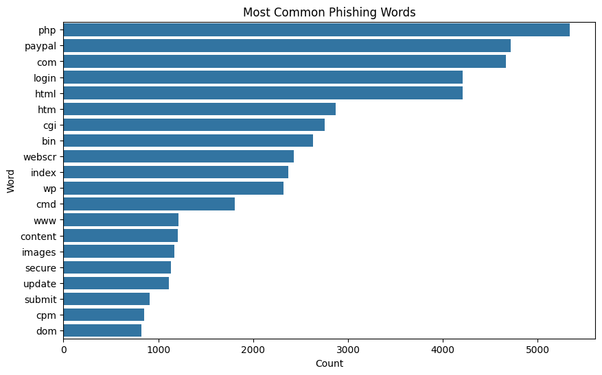

[figure not shown]

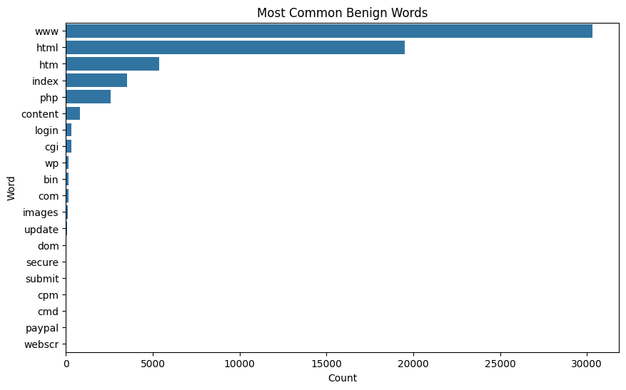

```python
import pandas as pd
from sklearn.feature_extraction.text import CountVectorizer
import matplotlib.pyplot as plt
import seaborn as sns
import tldextract
from urllib.parse import urlparse
from wordcloud import WordCloud

# Define the relevant columns
label_column = 'label'
text_column = 'domain'

# Function to remove TLD and protocol from the URL
def remove_tld_protocol(url):
    extracted = tldextract.extract(url)
    domain = f"{extracted.domain}.{extracted.suffix}"
    parsed_url = urlparse(url)
    path = parsed_url.path
    return path.replace(domain, '')

# Apply the function to the 'domain' column
df[text_column] = df[text_column].apply(remove_tld_protocol)

# Filter phishing and benign websites
df_phishing = df[df[label_column] == 1]
df_benign = df[df[label_column] == 0]

# Concatenate all phishing and benign texts into single strings
phishing_text = " ".join(df_phishing[text_column])
benign_text = " ".join(df_benign[text_column])

# Initialize CountVectorizer
vectorizer = CountVectorizer(stop_words='english', max_features=20)

# Fit and transform the phishing and benign texts
X_phishing = vectorizer.fit_transform([phishing_text])
X_benign = vectorizer.transform([benign_text])

# Get the feature names and word counts
common_words_phishing = vectorizer.get_feature_names_out()
common_words_benign = vectorizer.get_feature_names_out()
word_counts_phishing = X_phishing.toarray().flatten()
word_counts_benign = X_benign.toarray().flatten()

# Create DataFrames for better visualization
df_common_phishing = pd.DataFrame({'word': common_words_phishing, 'count': word_counts_phishing})
df_common_benign = pd.DataFrame({'word': common_words_benign, 'count': word_counts_benign})

# Sort the DataFrames by count
df_common_phishing = df_common_phishing.sort_values(by='count', ascending=False)
df_common_benign = df_common_benign.sort_values(by='count', ascending=False)

# Visualization of wordcloud and bar chart for phishing
plt.figure(figsize=(10, 6))
wordcloud = WordCloud(background_color="white").generate(" ".join(df_common_phishing['word']))
plt.imshow(wordcloud, interpolation='bilinear')
plt.axis("off")
plt.show()

plt.figure(figsize=(10, 6))
sns.barplot(x='count', y='word', data=df_common_phishing)
plt.title('Most Common Phishing Words')
plt.xlabel('Count')
plt.ylabel('Word')
plt.show()

# Visualization of wordcloud and bar chart for benign
plt.figure(figsize=(10, 6))
wordcloud = WordCloud(background_color="white").generate(" ".join(df_common_benign['word']))
plt.imshow(wordcloud, interpolation='bilinear')
plt.axis("off")
plt.show()

plt.figure(figsize=(10, 6))
sns.barplot(x='count', y='word', data=df_common_benign)
plt.title('Most Common Benign Words')
plt.xlabel('Count')
plt.ylabel('Word')
plt.show()
```

## Comparaison des mots clés fréquents dans les URLs de phishing et légitime:

L'analyse comparative des mots clés les plus fréquents dans les URLs de phishing et légitime révèle des tendances intéressantes et exploitables pour la détection de phishing:

**Différences notables:**

- **Mots clés liés aux paiements et à la connexion:** Les mots comme "paypal", "login", "wp", et "cgi" sont significativement plus fréquents dans les URLs de phishing. Cela confirme que les usurpations d'identité de sites de paiement et les tentatives de vol d'identifiants sont des tactiques courantes de phishing.
- **Utilisation de termes d'ingénierie sociale:** Les mots comme "secure", "update" et "content" sont présents dans les deux types d'URLs, mais leur fréquence plus élevée dans les URLs de phishing suggère une utilisation délibérée pour manipuler les utilisateurs.

##### Extractions des features potentiels

- **Compteur de mots suspects:** On compte combien de mots suspects sont présents dans l'URL. Plus il y en a, plus l'URL est louche.
- **Compteur de mots normaux:** On compte aussi les mots normaux. S'il y en a beaucoup, c'est peut-être une URL normale.
- **Combinaisons suspectes:** Parfois, deux mots suspects ensemble sont encore plus suspects.